# Assignment 1 Task 1

Justine Lang

2023-02-02

```r
knitr::opts_chunk$set(echo = TRUE, message = FALSE, warning = FALSE)

#Install packages

library(tidyverse)
library(here)
library(cowplot)
library(readxl)
library(lubridate)
```

## Data Overview

This data exploration will analyze amphibian abundance data gathered by the Sierra Lakes Inventory Project (SLIP) from 1995 to 2002. SLIP surveyed aquatic communities for more than 8000 freshwater bodies in the southern Sierra Nevada and has supported the research and management of Sierra Nevada aquatic ecosystems (Knapp et al., 2020). This exploration of SLIP data will specifically visualize mountain yellow-legged frog (*Rana muscosa*) abundance in Sierra Nevada lakes.

## Part 1: Creating a graph of *R. muscosa* count by life stage

### Data Wrangling

Filter and group data to find the total *R. muscosa* count each year across all water bodies, by life stage (adult, subadult, and tadpole).

```r
#Read in the data

amphibians <- read_xlsx(here("data", "sierra_amphibians.xlsx"))
```

```r
#Filter data by species and life stage, excluding EggMass; make a column with just the year

ramu <- amphibians %>%
  filter(amphibian_species=="RAMU", amphibian_life_stage !="EggMass") %>%
  mutate(date = ymd(survey_date)) %>%
  mutate(year = year(date)) %>%
  select(year, amphibian_species, amphibian_life_stage, amphibian_number, lake_id) %>%
  drop_na()

#Group by year and life stage to get the counts

ramu_counts <- ramu %>%
  group_by(year, amphibian_life_stage) %>%
  summarize(count = sum(amphibian_number))
```

### Create a Graph

Graph the total *R. muscosa* count each year across all water bodies, by life stage (adult, subadult, and tadpole).

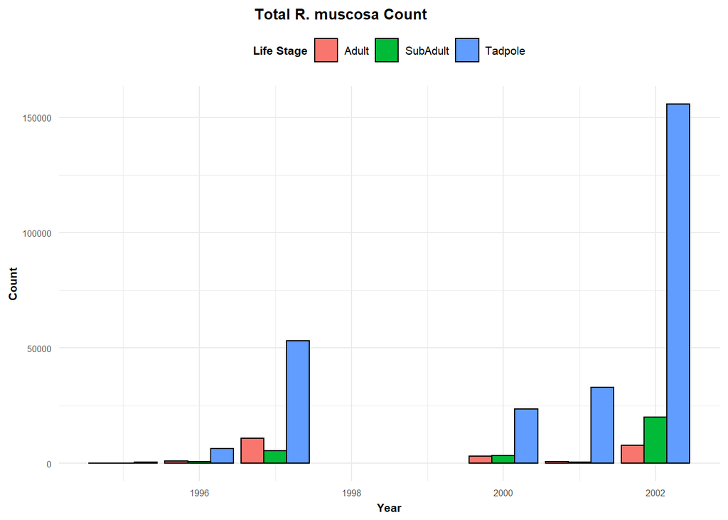

```r
ramu_counts_gg <- ggplot(data = ramu_counts, aes(fill = amphibian_life_stage, x = year, y = count, color = amphibian_life_stage)) +
  geom_col(stat = "identity", position = "dodge", color = "black") +
  labs(x = "Year", y = "Count", title = "Total R. muscosa Count", fill = "Life Stage") +
  theme_minimal() +
  theme(plot.title = element_text(hjust = 0.4, face = "bold", size = 10),
        axis.title.x = element_text(vjust = 0.2, face = "bold", size = 8),
        axis.title.y = element_text(face = "bold", size = 8),
        legend.title = element_text(size = 8, face = "bold"),
        legend.text = element_text(size = 8),
        legend.position = "top",
        axis.text = element_text(size = 6))

ramu_counts_gg
```

## Part 2: Creating a graph of total counts in top 5 lakes

### Data Wrangling

Filter and group data to find total counts of combined adult and subadult *R. muscosa* in the 5 lakes with the greatest total observed counts, over all years of the study.

```r
#Filter data to include only adults and subadults

ramu_adult <- ramu %>%
  filter(amphibian_life_stage != "Tadpole")

#Rename lake_id columns to include "Lake"

ramu_adult$lake_id <- sub("^", "Lake ", ramu_adult$lake_id)

#Find top five lakes

top_5_lakes <- ramu_adult %>%
  group_by(lake_id) %>%
  summarize(count = sum(amphibian_number)) %>%
  slice_max(count, n = 5) %>%
  arrange(count)
```

### Create a Graph

Graph the total counts of combined adult and subadult *R. muscosa* in the 5 lakes with the greatest total observed counts, over all years of the study.

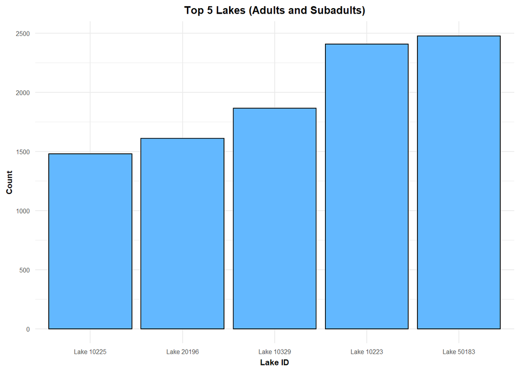

```r
top_lakes_gg <- ggplot(data = top_5_lakes, aes(x = reorder(lake_id, count), y = count)) +
  geom_col(stat = "identity", color = "black", fill = "steelblue1") +
  labs(x = "Lake ID", y = "Count", title = "Top 5 Lakes (Adults and Subadults)") +
  theme_minimal() +
  theme(plot.title = element_text(hjust = 0.5, face = "bold", size = 10),
        axis.title.x = element_text(vjust = 0.2, face = "bold", size = 8),
        axis.title.y = element_text(face = "bold", size = 8),
        axis.text = element_text(size = 6))

top_lakes_gg
```

## Part 3: Combine graphs

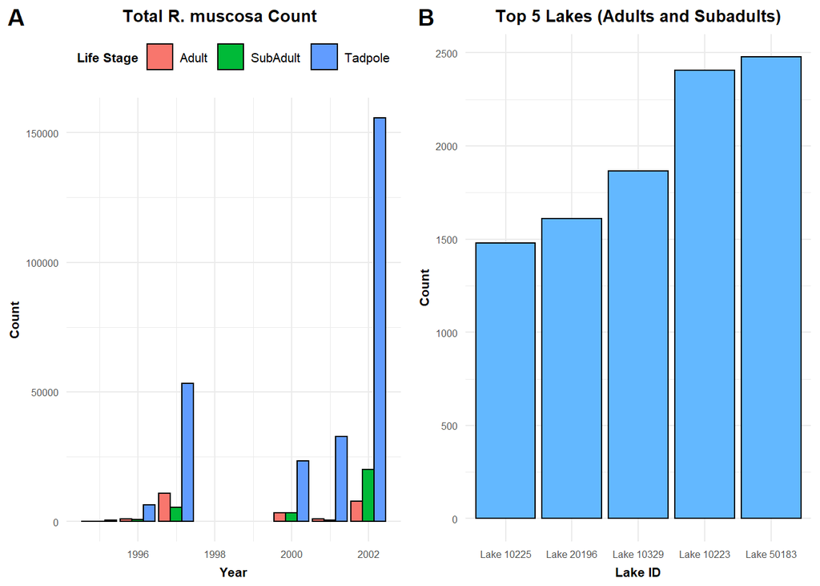

Figure 1: Mountain yellow-legged frog (Rana muscosa) counts from 1995-2002. A. Shows total counts each year across all water bodies, by life stage. B. Shows combined adult and subadult counts observed in the 5 lakes with the greatest total observed counts over all years of the study.

```r
plot_grid(ramu_counts_gg, top_lakes_gg, labels = c('A', 'B'))
```

## Citation

Knapp, R.A., C. Pavelka, E.E. Hegeman, and T.C. Smith. 2020. The Sierra Lakes Inventory Project: Non-Native fish and community composition of lakes and ponds in the Sierra Nevada, California ver 2. Environmental Data Initiative. https://doi.org/10.6073/pasta/d835832d7fd00d9e4466e44eea87fab3